# ID11 Player Valuation Model

Nicholas Kondo, Luke G, Darron K

Here are all the libraries we are using.

```r
# loading all libraries
library(tidyverse)
library(dplyr)
library(tidyr)
library(worldfootballR)
library(dplyr)
library(tidyverse)
library(utils)
library(rsample)
library(glmnet)
library(glmnetUtils)
library(forcats)
library(rsample)
library(ggplot2)
library(sjPlot)
library(partykit)
library(titanic)
library(PerformanceAnalytics)
library(rpart)
library(rpart.plot)
library(randomForest)

# note, do not run install.packages() inside a code chunk. install them in the console outside of a code chunk.
```

# Introduction

For this study, data was collected from FBref.com on the “Big 5” Leagues. Our data includes statistics in categories such as `standard`, `shooting`, `passing`, `goal and shot creation`, `defense`, `miscellaneous`, `playing time`, and `market values`. We compare a player’s statistics with their market values listed on TransferMarkt.com and find the statistics that are most correlated with a player’s market values. In other words, we are aiming to find the certain statistics that makes a player valuable.

Here we are loading the tables by calling the function `fb_big5_advanced_season_stats` from our `worldfootballR` package. We are taking data from 2018 to 2020. The chunks are split up because for computational purposes.

```r
#Loading the data sets

standard <- fb_big5_advanced_season_stats(season_end_year = c(2018:2020), stat_type = "standard", team_or_player = "player")

shooting <- fb_big5_advanced_season_stats(season_end_year = c(2018:2020), stat_type = "shooting", team_or_player = "player")

passing <- fb_big5_advanced_season_stats(season_end_year = c(2018:2020), stat_type = "passing", team_or_player = "player")

passingtypes <- fb_big5_advanced_season_stats(season_end_year = c(2018:2020), stat_type = "passing_types", team_or_player = "player")

gca <- fb_big5_advanced_season_stats(season_end_year = c(2018:2020), stat_type = "gca", team_or_player = "player")
```

```r
defense <- fb_big5_advanced_season_stats(season_end_year = c(2018:2020), stat_type = "defense", team_or_player = "player")
possession <- fb_big5_advanced_season_stats(season_end_year = c(2018:2020), stat_type = "possession", team_or_player = "player")
```

```r
misc <- fb_big5_advanced_season_stats(season_end_year = c(2018:2020), stat_type = "misc", team_or_player = "player")
playingtime <- fb_big5_advanced_season_stats(season_end_year = c(2018:2020), stat_type = "playing_time", team_or_player = "player")
keepers <- fb_big5_advanced_season_stats(season_end_year = c(2018:2020), stat_type = "keepers", team_or_player = "player")
keepers_adv <- fb_big5_advanced_season_stats(season_end_year = c(2018:2020), stat_type = "keepers_adv", team_or_player = "player")
```

Here we are loading the market values table from transfermarkt.com by calling the `get_player_market_values` function.

```r
market_values17 <- get_player_market_values(country_name = c("England", "Spain", "France", "Italy", "Germany"), start_year = 2017)
```

```r
market_values18 <- get_player_market_values(country_name = c("England", "Spain", "France", "Italy", "Germany"), start_year = 2018)
```

```r
market_values19 <- get_player_market_values(country_name = c("England", "Spain", "France", "Italy", "Germany"), start_year = 2019)
```

```r
market_values <- rbind(market_values17, market_values18, market_values19)
```

Renaming variables.

```r
# Renaming the variables

standard <- standard %>%
  rename(Matches_Played = MP_Playing,
         Starts = Starts_Playing,
         Min = Min_Playing,
         Min_per_90 = Mins_Per_90_Playing,
         xG = xG_Expected,
         npxG = npxG_Expected,
         xA = xA_Expected,
         'npxG+xA' = 'npxG+xA_Expected')

shooting <- shooting %>%
  rename(Gls = Gls_Standard,
         Sh = Sh_Standard,
         SoT = SoT_Standard,
         SoT_percent = SoT_percent_Standard,
         SoT_per_90 = SoT_per_90_Standard,
         Sh_per_90_Standard = Sh_per_90_Standard,
         SoT_per_90 = SoT_per_90_Standard,
         G_per_Sh = G_per_Sh_Standard,
         G_per_SoT = G_per_SoT_Standard,
         Dist = Dist_Standard,
         FK = FK_Standard,
         PK = PK_Standard,
         PKatt = PKatt_Standard,
         xG = xG_Expected,
         npxG = npxG_Expected,
         npxG_per_Sh = npxG_per_Sh_Expected,
         G_minus_xG = G_minus_xG_Expected,
         npG_minus_xG = 'np:G_minus_xG_Expected')

defense <- defense %>%
  rename(
Tkl = Tkl_Tackles,
TklW = TklW_Tackles,
Def_3rd = 'Def 3rd_Tackles',
Mid_3rd = 'Mid 3rd_Tackles',
Att_3rd = 'Att 3rd_Tackles',
Tkl_vs_dribble = Tkl_Vs,
Att_vs_dribble = Att_Vs,
Successful_Pressure_Percent = Tkl_percent_Vs,
Def_3rd_Pressures = 'Def 3rd_Pressures',
Mid_3rd_Pressures = 'Mid 3rd_Pressures',
Att_3rd_Pressures = 'Att 3rd_Pressures',
Blocks = Blocks_Blocks)

possession <- possession %>%
  rename(
    Touches = Touches_Touches,
    Def_3rd_Touches = 'Def 3rd_Touches',
    Mid_3rd_Touches = 'Mid 3rd_Touches',
    Att_3rd_Touches = 'Att 3rd_Touches',
    Att_Pen_Touches = 'Att Pen_Touches',
    Carries = Carries_Carries)

keepers <- keepers %>%
  rename(Matches_Played = MP_Playing,
         Starts = Starts_Playing,
         Min = Min_Playing,
         Min_per_90 = Mins_Per_90_Playing)

keepers_adv <- keepers_adv %>%
  rename(GA = GA_Goals,
         PKA = PKA_Goals,
         FK = FK_Goals,
         CK = CK_Goals,
         OG = OG_Goals,
         PSxG = PSxG_Expected,
         PSxG_per_SoT = PSxG_per_SoT_Expected,
         PSxG_plus_minus = `PSxG+_per__minus__Expected`,
         per_90 = '_per_90_Expected')

passing <- passing %>%
  rename(Cmp = Cmp_Total,
         Cmp_percent = Cmp_percent_Total,
         TotDist = TotDist_Total,
         PrgDist = PrgDist_Total)

playingtime <- playingtime %>%
  rename(Matches_Played = MP_Playing.Time,
         Min = Min_Playing.Time,
         Min_per_90 = Mins_Per_90_Playing.Time,
         Starts = Starts_Starts,
         Min_per_Match_Start = Mn_per_Start_Starts,
         Compl = Compl_Starts,
         Subs = Subs_Subs,
         Mn_per_Sub = Mn_per_Sub_Subs,
         unSub = unSub_Subs,
         PPM = PPM_Team.Success,
         onG = onG_Team.Success,
         onGA = onGA_Team.Success,
         plus_per_minus = plus_per__minus__Team.Success,
         plus_per_minus_per_90 = plus_per__minus_90_Team.Success,
         On_minus_Off = On_minus_Off_Team.Success,
         onxG = onxG_Team.Success..xG.,
         onxGA = onxGA_Team.Success..xG,
         xGplus_per_minus = xGplus_per__minus__Team.Success..xG,
         xGplus_per_minus_per_90 = xGplus_per__minus_90_Team.Success..xG,
         xG_On_minus_Off = On_minus_Off_Team.Success..xG)
```

Here we are unclassing all the variables and then setting the variables with string values as factors. This stores less data and allows us to run models on the data.

```r
# Storing the character data types as factors to save more storage and call objects more efficiently
market_values <- as.data.frame(unclass(market_values),stringsAsFactors = TRUE)
defense <- as.data.frame(unclass(defense),stringsAsFactors = TRUE)
gca <- as.data.frame(unclass(gca),stringsAsFactors = TRUE)
keepers <- as.data.frame(unclass(keepers),stringsAsFactors = TRUE)
keepers_adv <- as.data.frame(unclass(keepers_adv),stringsAsFactors = TRUE)
misc <- as.data.frame(unclass(misc),stringsAsFactors = TRUE)
passing <- as.data.frame(unclass(passing),stringsAsFactors = TRUE)
passingtypes <- as.data.frame(unclass(passingtypes),stringsAsFactors = TRUE)
playingtime <- as.data.frame(unclass(playingtime),stringsAsFactors = TRUE)
possession <- as.data.frame(unclass(possession), stringsAsFactors = TRUE)
shooting <- as.data.frame(unclass(shooting), stringsAsFactors = TRUE)
standard <- as.data.frame(unclass(standard), stringsAsFactors = TRUE)
```

We are going to filter the players by position. Here are the different positions listed on Transfermarkt and the number of players at the respective position.

```r
table(market_values$player_position)
```

```
##
##             attack Attacking Midfield   Central Midfield
##                  1                624               1532
##        Centre-Back     Centre-Forward            defence
##               1959               1528                  1
## Defensive Midfield         Goalkeeper      Left Midfield
##                877               1244                106
##        Left Winger          Left-Back           midfield
##                660                828                  4
##     Right Midfield       Right Winger         Right-Back
##                 54                721                872
##     Second Striker
##                131
```

Notice that there are some ‘strange’ values at some positions. Specifically:

`attack` : 1 player

```r
strange <- market_values %>%
  select(player_name, comp_name, player_position, current_club, player_market_value_euro, player_age) %>%
  filter(player_position == 'midfield' | player_position == 'attack' | player_position == 'defence')

head(strange, 8)
```

```
##        player_name comp_name player_position     current_club
## 1            Verza    LaLiga        midfield     Without Club
## 2    Samuel Robert   Ligue 1          attack  Racing Besançon
## 3 Federico Chiossi   Serie A        midfield Real Calepina FC
## 4      Jawad Dramé   Ligue 1        midfield       OGC Nice B
## 5   Mathurin Sakho   Ligue 1         defence         US Camon
## 6      Théo Godard   Ligue 1        midfield     Without Club
##   player_market_value_euro player_age
## 1                   600000         31
## 2                       NA         20
## 3                    50000         20
## 4                       NA         19
## 5                       NA         24
## 6                       NA         18
```

Are these players we can remove? Non-relevant players? Most players we don’t even have a valuation. We will not include these players.

We are creating a unique identifier for each table here. This is so that we can use the identifier to merge the tables and join them together later on.

```r
# Here we are creating a unique identifier for each table so they can be joined

market_values <- market_values %>%
  mutate(Season_End_Year = season_start_year + 1,
         PlayerYearComp_id = paste(player_name, Season_End_Year, comp_name))

standard <- standard %>%
  mutate(PlayerYearComp_id = paste(Player, Season_End_Year, Comp))

shooting <- shooting %>%
  mutate(PlayerYearComp_id = paste(Player, Season_End_Year, Comp))

passing <- passing %>%
  mutate(PlayerYearComp_id = paste(Player, Season_End_Year, Comp))

passingtypes <- passingtypes %>%
  mutate(PlayerYearComp_id = paste(Player, Season_End_Year, Comp))

gca <- gca %>%
  mutate(PlayerYearComp_id = paste(Player, Season_End_Year, Comp))

defense <- defense %>%
  mutate(PlayerYearComp_id = paste(Player, Season_End_Year, Comp))

possession <- possession %>%
  mutate(PlayerYearComp_id = paste(Player, Season_End_Year, Comp))

playingtime <- playingtime %>%
  mutate(PlayerYearComp_id = paste(Player, Season_End_Year, Comp))

misc <- misc %>%
  mutate(PlayerYearComp_id = paste(Player, Season_End_Year, Comp))

keepers <- keepers %>%
  mutate(PlayerYearComp_id = paste(Player, Season_End_Year, Comp))

keepers_adv <- keepers_adv %>%
  mutate(PlayerYearComp_id = paste(Player, Season_End_Year, Comp))
```

# Join

Here we are joining and merging all the data sets together using the `inner join` function. We named this table master, and for duplicate values, we added a suffix: `REMOVEDUPLICATE`, which will appear in all of the duplicate variables. Then, a code is executed to remove anything containing those string of letters. This merges all our tables together and remvoes duplicate variables.

```r
# Here we are merging the relevant tables to goal keepers
# For every duplicate variable we are adding a suffix on the end ".REMOVEDUPLICATE"
# We will write a code later that removes any variable with this suffix, thus removing all the variables

# Standard
# Shooting
master <- inner_join(x = standard,
                             y = shooting,
                             by = "PlayerYearComp_id",
                             suffix = c("",".REMOVEDUPLICATE"))

# Passing
master <- inner_join(x = master,
                             y = passing,
                             by = "PlayerYearComp_id",
                             suffix = c("",".REMOVEDUPLICATE"))

# Passing Types
master <- inner_join(x = master,
                             y = passingtypes,
                             by = "PlayerYearComp_id",
                             suffix = c("",".REMOVEDUPLICATE"))

# GCA
master <- inner_join(x = master,
                             y = gca,
                             by = "PlayerYearComp_id",
                             suffix = c("",".REMOVEDUPLICATE"))

# Defense
master <- inner_join(x = master,
                             y = defense,
                             by = "PlayerYearComp_id",
                             suffix = c("",".REMOVEDUPLICATE"))

# Possession
master <- inner_join(x = master,
                             y = possession,
                             by = "PlayerYearComp_id",
                             suffix = c("",".REMOVEDUPLICATE"))

# Playing Time
master <- inner_join(x = master,
                             y = playingtime,
                             by = "PlayerYearComp_id",
                             suffix = c("",".REMOVEDUPLICATE"))

# Market Values
master <- inner_join(x = master,
                             y = market_values,
                             by = "PlayerYearComp_id",
                             suffix = c("",".REMOVEDUPLICATE"))

# Removing duplicate variables
master <- master %>% select(-contains("REMOVEDUPLICATE"))
```

# Filter

Let’s separate each player by position.

```r
attacking_midfield <- master %>%
  filter(player_position == 'Attacking Midfield')

central_midfield <- master %>%
  filter(player_position == 'Central Midfield')

centre_back <- master %>%
  filter(player_position == 'Centre-Back')

centreForward_secondStriker <- master %>%
  filter(player_position == 'Centre-Forward' | player_position == 'Second Striker')

right_left_back <- master %>%
  filter(player_position == 'Right-Back' | player_position == 'Left-Back')

right_left_midfielder <- master %>%
  filter(player_position == 'Right Midfield' | player_position == 'Left Midfield')

winger <- master %>%
  filter(player_position == 'Right Winger' | player_position == 'Left Winger')
```

# Random Forest

### Attacking Midfield

```r
# Removing unnecessary variables
attacking_midfield1 <- attacking_midfield %>%
    select(-region, -PlayerYearComp_id, -Url, -Season_End_Year, -Squad,
           -Player, -Nation, -Pos, -Age, -Born, -player_dob, -player_name,
           -player_num, -squad, -country, -comp_name, -player_nationality,
           -current_club, -player_height_mtrs, -date_joined, -joined_from,
           -contract_expiry, -player_url)

# Random Forest
RF_attacking_midfield <- randomForest(player_market_value_euro ~ .,
                       data = attacking_midfield1,
                       type = regression,
                       mtry = 5,
                       na.action = na.roughfix,
                       ntree = 200)

# Plot
print(RF_attacking_midfield)
```

```
##
## Call:
##  randomForest(formula = player_market_value_euro ~ ., data = attacking_midfield1,      type = regression, mtry = 5, ntree = 200, na.action = na.roughfix)
##                Type of random forest: regression
##                      Number of trees: 200
## No. of variables tried at each split: 5
##
##           Mean of squared residuals: 9885578717582
##                     % Var explained: 91.26
```

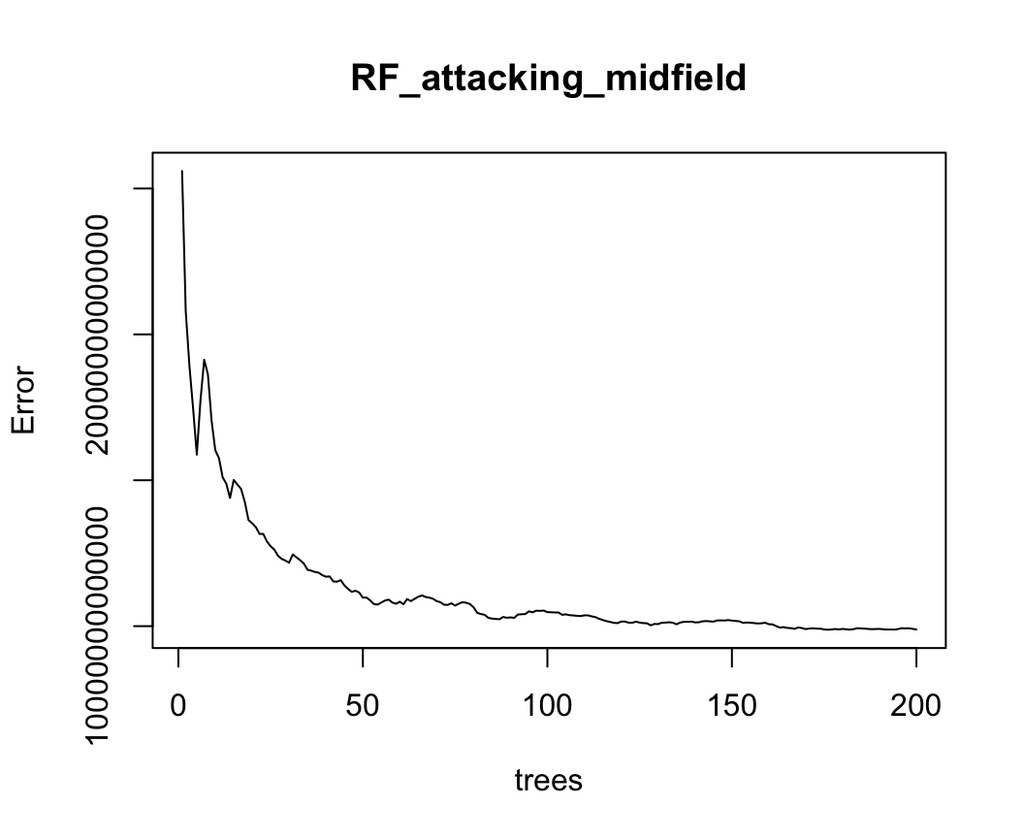

```r
plot(RF_attacking_midfield)
```

### Central Midfield

```r
# Removing unnecessary variables
central_midfield1 <- central_midfield %>%
    select(-region, -PlayerYearComp_id, -Url, -Season_End_Year, -Squad,
           -Player, -Nation, -Pos, -Age, -Born, -player_dob, -player_name,
           -player_num, -squad, -country, -comp_name, -player_nationality,
           -current_club, -player_height_mtrs, -date_joined, -joined_from,
           -contract_expiry, -player_url)

# Random Forest
RF_central_midfield <- randomForest(player_market_value_euro ~ .,
                       data = central_midfield1,
                       type = regression,
                       mtry = 5,
                       na.action = na.roughfix,
                       ntree = 200)

# Plot
print(RF_central_midfield)
```

```
##
## Call:
##  randomForest(formula = player_market_value_euro ~ ., data = central_midfield1,      type = regression, mtry = 5, ntree = 200, na.action = na.roughfix)
##                Type of random forest: regression
##                      Number of trees: 200
## No. of variables tried at each split: 5
##
##           Mean of squared residuals: 4373367625739
##                     % Var explained: 94.14
```

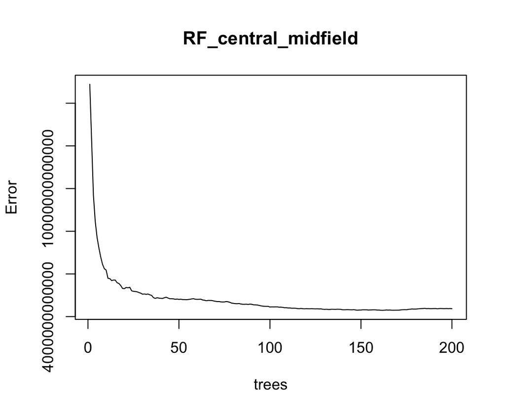

```r
plot(RF_central_midfield)
```

### Centre Back

```r
# Removing unnecessary variables
centre_back1 <- centre_back %>%
    select(-region, -PlayerYearComp_id, -Url, -Season_End_Year, -Squad,
           -Player, -Nation, -Pos, -Age, -Born, -player_dob, -player_name,
           -player_num, -squad, -country, -comp_name, -player_nationality,
           -current_club, -player_height_mtrs, -date_joined, -joined_from,
           -contract_expiry, -player_url)

# Random Forest
RF_centre_back <- randomForest(player_market_value_euro ~ .,
                       data = centre_back1,
                       type = regression,
                       mtry = 5,
                       na.action = na.roughfix,
                       ntree = 200)

# Plot
print(RF_centre_back)
```

```
##
## Call:
##  randomForest(formula = player_market_value_euro ~ ., data = centre_back1,      type = regression, mtry = 5, ntree = 200, na.action = na.roughfix)
##                Type of random forest: regression
##                      Number of trees: 200
## No. of variables tried at each split: 5
##
##           Mean of squared residuals: 5454418388472
##                     % Var explained: 94.82
```

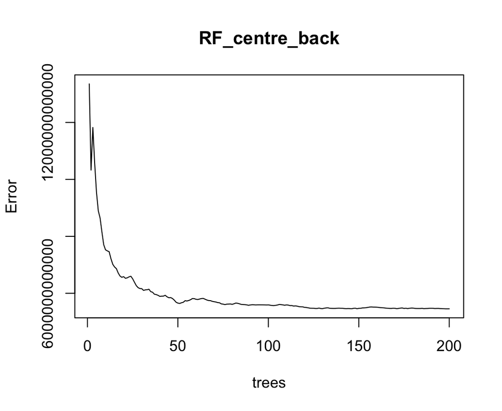

```r
plot(RF_centre_back)
```

### Centre Forward and Second Striker

```r
# Removing unnecessary variables
centreForward_secondStriker1 <- centreForward_secondStriker %>%
    select(-region, -PlayerYearComp_id, -Url, -Season_End_Year, -Squad,
           -Player, -Nation, -Pos, -Age, -Born, -player_dob, -player_name,
           -player_num, -squad, -country, -comp_name, -player_nationality,
           -current_club, -player_height_mtrs, -date_joined, -joined_from,
           -contract_expiry, -player_url)

# Random Forest
RF_centreForward_secondStriker <- randomForest(player_market_value_euro ~ .,
                       data = centreForward_secondStriker1,
                       type = regression,
                       mtry = 5,
                       na.action = na.roughfix,
                       ntree = 200)

# Plot
print(RF_centreForward_secondStriker)
```

```
##
## Call:
##  randomForest(formula = player_market_value_euro ~ ., data = centreForward_secondStriker1,      type = regression, mtry = 5, ntree = 200, na.action = na.roughfix)
##                Type of random forest: regression
##                      Number of trees: 200
## No. of variables tried at each split: 5
##
##           Mean of squared residuals: 7351586115629
##                     % Var explained: 98.47
```

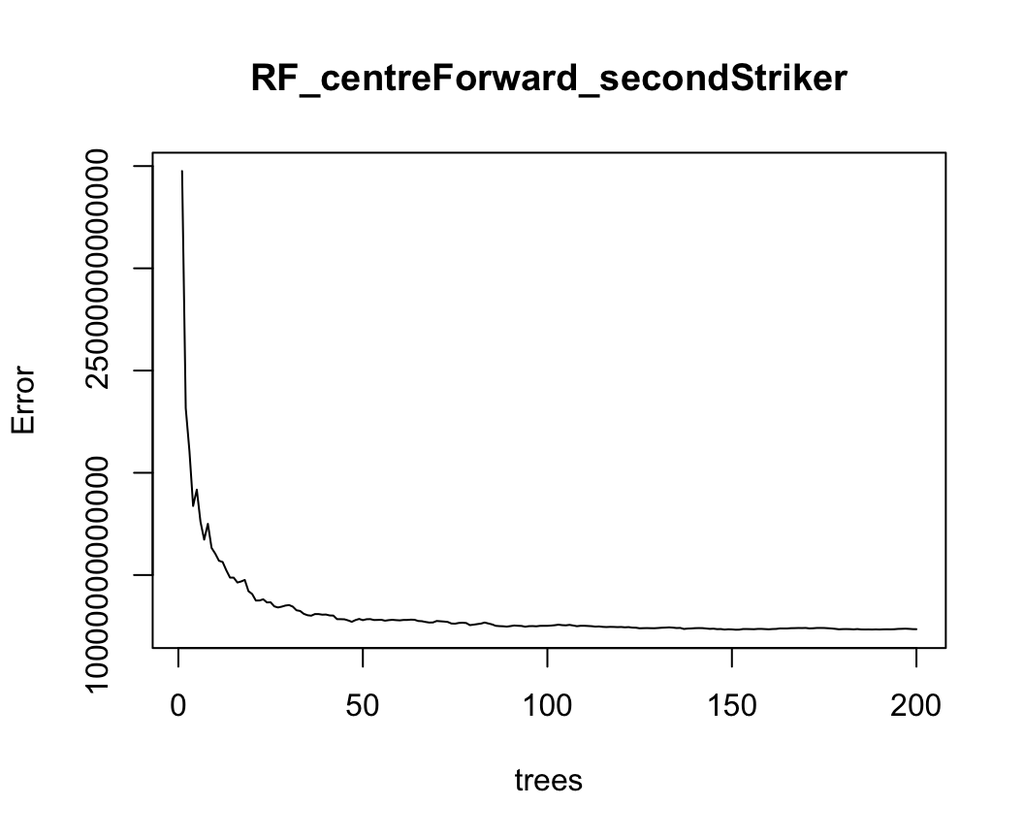

```r
plot(RF_centreForward_secondStriker)
```

### Right and Left Back

```r
# Removing unnecessary variables
right_left_back1 <- right_left_back %>%
    select(-region, -PlayerYearComp_id, -Url, -Season_End_Year, -Squad,
           -Player, -Nation, -Pos, -Age, -Born, -player_dob, -player_name,
           -player_num, -squad, -country, -comp_name, -player_nationality,
           -current_club, -player_height_mtrs, -date_joined, -joined_from,
           -contract_expiry, -player_url)

# Random Forest
RF_right_left_back <- randomForest(player_market_value_euro ~ .,
                       data = right_left_back1,
                       type = regression,
                       mtry = 5,
                       na.action = na.roughfix,
                       ntree = 200)

# Plot
print(RF_right_left_back)
```

```
##
## Call:
##  randomForest(formula = player_market_value_euro ~ ., data = right_left_back1,      type = regression, mtry = 5, ntree = 200, na.action = na.roughfix)
##                Type of random forest: regression
##                      Number of trees: 200
## No. of variables tried at each split: 5
##
##           Mean of squared residuals: 3584599927854
##                     % Var explained: 85.97
```

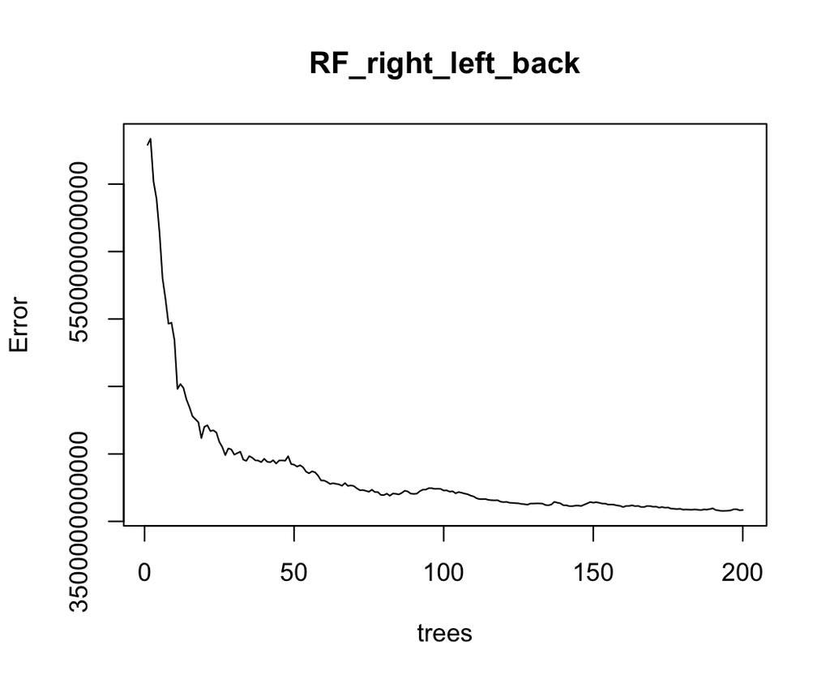

```r
plot(RF_right_left_back)
```

### Right/Left Midfielders

```r
# Removing unnecessary variables
right_left_midfielder1 <- right_left_midfielder %>%
    select(-region, -PlayerYearComp_id, -Url, -Season_End_Year, -Squad,
           -Player, -Nation, -Pos, -Age, -Born, -player_dob, -player_name,
           -player_num, -squad, -country, -comp_name, -player_nationality,
           -current_club, -player_height_mtrs, -date_joined, -joined_from,
           -contract_expiry, -player_url)

# Random Forest
RF_right_left_midfielder <- randomForest(player_market_value_euro ~ .,
                       data = right_left_midfielder1,
                       type = regression,
                       mtry = 5,
                       na.action = na.roughfix,
                       ntree = 200)

# Plot
print(RF_right_left_midfielder)
```

```
##
## Call:
##  randomForest(formula = player_market_value_euro ~ ., data = right_left_midfielder1,      type = regression, mtry = 5, ntree = 200, na.action = na.roughfix)
##                Type of random forest: regression
##                      Number of trees: 200
## No. of variables tried at each split: 5
##
##           Mean of squared residuals: 3156034868807
##                     % Var explained: 64.17
```

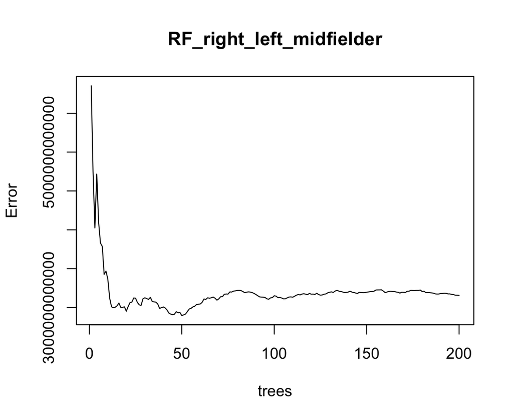

```r
plot(RF_right_left_midfielder)
```

### Right/Left Wingers

```r
# Removing unnecessary variables
winger1 <- winger %>%
    select(-region, -PlayerYearComp_id, -Url, -Season_End_Year, -Squad,
           -Player, -Nation, -Pos, -Age, -Born, -player_dob, -player_name,
           -player_num, -squad, -country, -comp_name, -player_nationality,
           -current_club, -player_height_mtrs, -date_joined, -joined_from,
           -contract_expiry, -player_url)

# Random Forest
RF_winger <- randomForest(player_market_value_euro ~ .,
                       data = winger1,
                       type = regression,
                       mtry = 5,
                       na.action = na.roughfix,
                       ntree = 200)

# Plot
print(RF_winger)
```

```
##
## Call:
##  randomForest(formula = player_market_value_euro ~ ., data = winger1,      type = regression, mtry = 5, ntree = 200, na.action = na.roughfix)
##                Type of random forest: regression
##                      Number of trees: 200
## No. of variables tried at each split: 5
##
##           Mean of squared residuals: 8474342087432
##                     % Var explained: 87.41
```

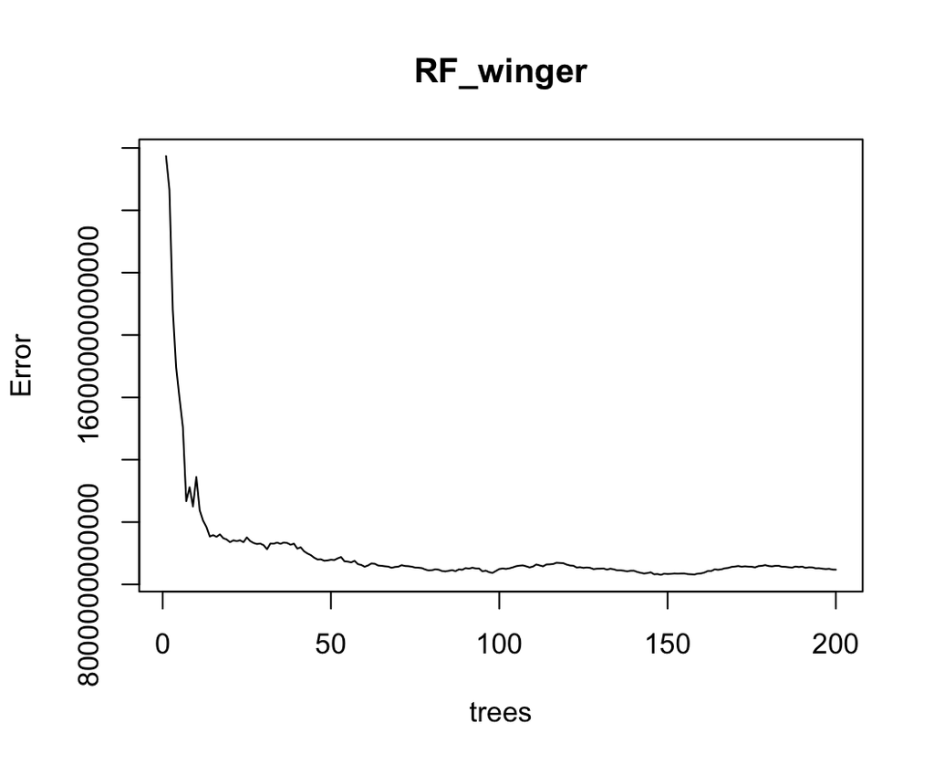

```r
plot(RF_winger)
```

# Model Tuning

### Attacking Midfield

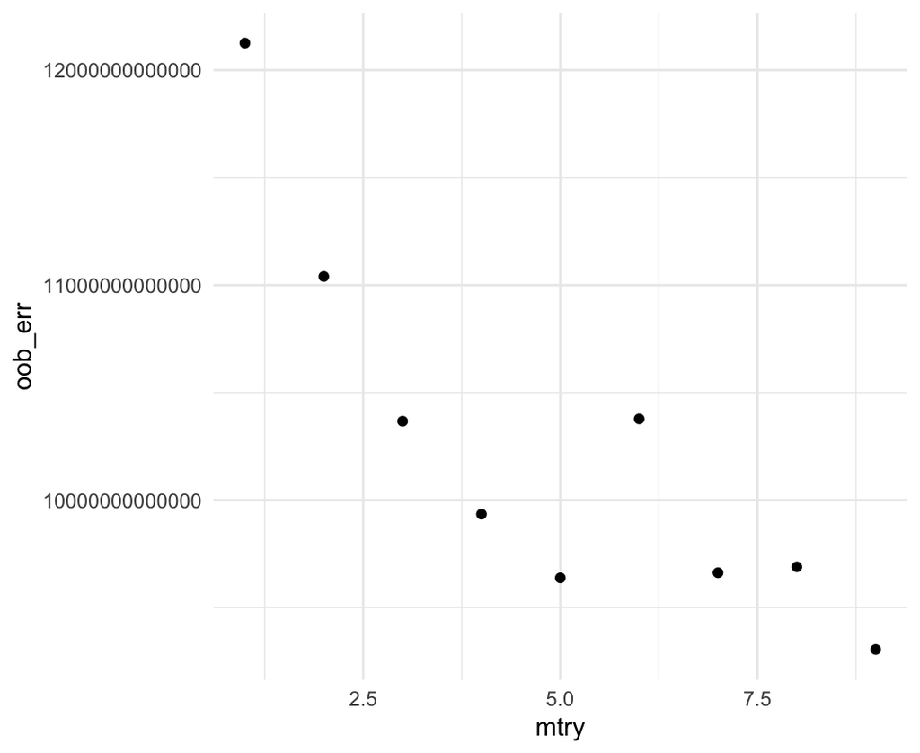

```r
# All Variables
rf_mods <- list()
oob_err <- NULL
test_err <- NULL
for(mtry in 1:9){
  RFfit_attacking_midfield <- randomForest(player_market_value_euro ~
                           .,
                         data = attacking_midfield1,
                         mtry = mtry,
                         na.action = na.roughfix,
                         ntree = 200)
  oob_err[mtry] <- RFfit_attacking_midfield$mse[200]

  cat(mtry," ")
}
## 1  2  3  4  5  6  7  8  9
## 1  2  3  4  5  6  7  8  9
results_DF <- data.frame(mtry = 1:9, oob_err)
ggplot(results_DF, aes(x = mtry, y = oob_err)) + geom_point() + theme_minimal() + xlim(1,9)
```

### Central Midfield

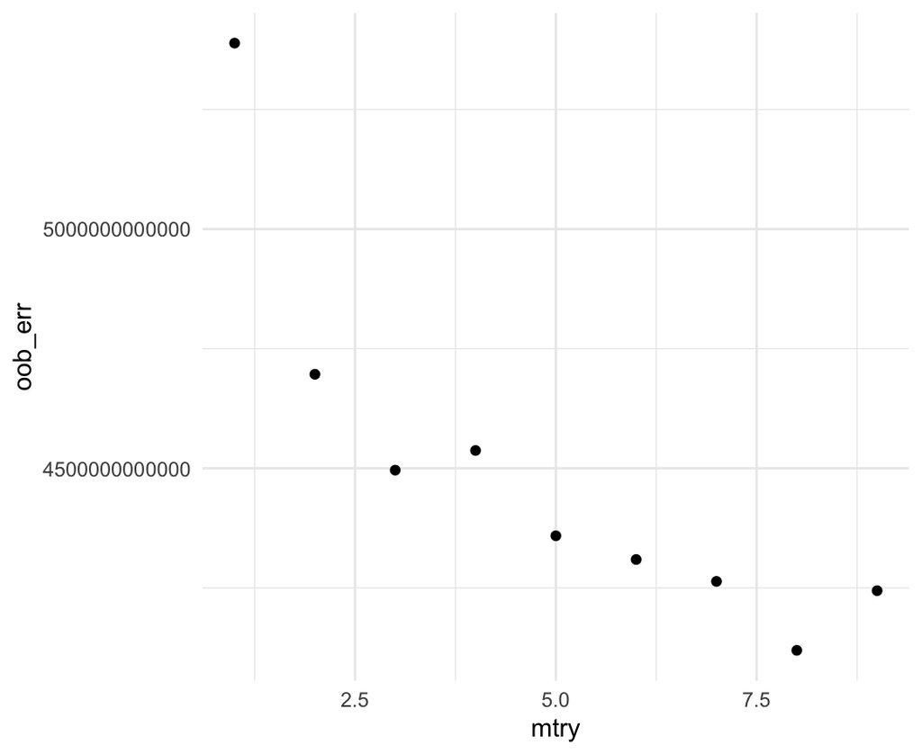

```r
# All Variables
rf_mods <- list()
oob_err <- NULL
test_err <- NULL
for(mtry in 1:9){
  RFfit_central_midfield <- randomForest(player_market_value_euro ~
                           .,
                         data = central_midfield1,
                         mtry = mtry,
                         na.action = na.roughfix,
                         ntree = 200)
  oob_err[mtry] <- RFfit_central_midfield$mse[200]

  cat(mtry," ")
}
## 1  2  3  4  5  6  7  8  9
## 1  2  3  4  5  6  7  8  9
results_DF <- data.frame(mtry = 1:9, oob_err)
ggplot(results_DF, aes(x = mtry, y = oob_err)) + geom_point() + theme_minimal() + xlim(1,9)
```

### Centre Back

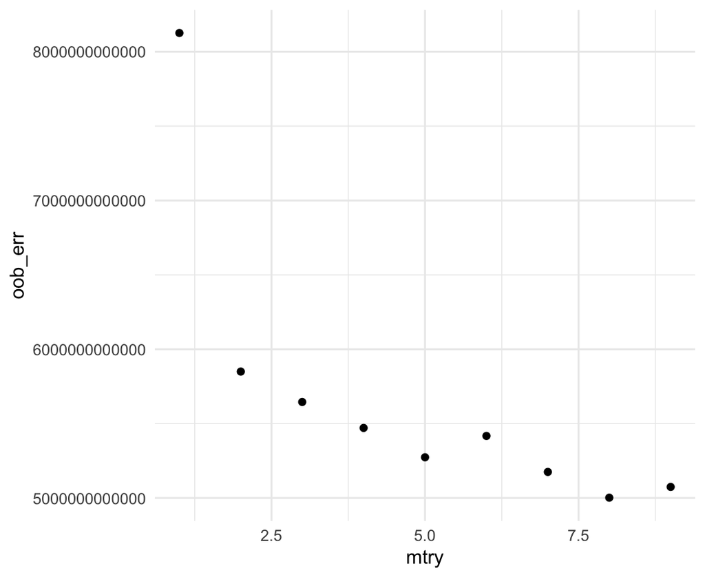

```r
# All Variables
rf_mods <- list()
oob_err <- NULL
test_err <- NULL
for(mtry in 1:9){
  RFfit_centre_back <- randomForest(player_market_value_euro ~
                           .,
                         data = centre_back1,
                         mtry = mtry,
                         na.action = na.roughfix,
                         ntree = 200)
  oob_err[mtry] <- RFfit_centre_back$mse[200]

  cat(mtry," ")
}
## 1  2  3  4  5  6  7  8  9
## 1  2  3  4  5  6  7  8  9
results_DF <- data.frame(mtry = 1:9, oob_err)
ggplot(results_DF, aes(x = mtry, y = oob_err)) + geom_point() + theme_minimal() + xlim(1,9)
```

### Centre Forward and Second Striker

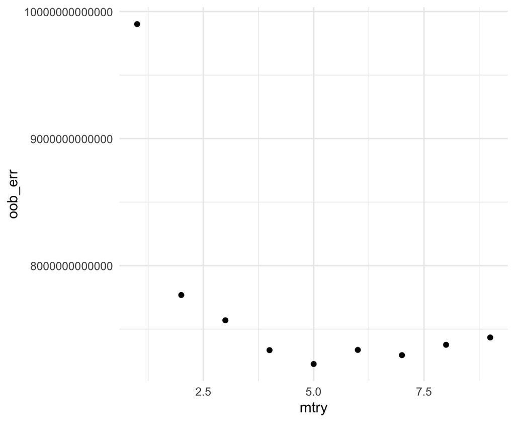

```r
# All Variables
rf_mods <- list()
oob_err <- NULL
test_err <- NULL
for(mtry in 1:9){
  RFfit_centreForward_secondStriker  <- randomForest(player_market_value_euro ~
                           .,
                         data = centreForward_secondStriker1,
                         mtry = mtry,
                         na.action = na.roughfix,
                         ntree = 200)
  oob_err[mtry] <- RFfit_centreForward_secondStriker$mse[200]

  cat(mtry," ")
}
## 1  2  3  4  5  6  7  8  9
## 1  2  3  4  5  6  7  8  9
results_DF <- data.frame(mtry = 1:9, oob_err)
ggplot(results_DF, aes(x = mtry, y = oob_err)) + geom_point() + theme_minimal() + xlim(1,9)
```

### Right/Left Back

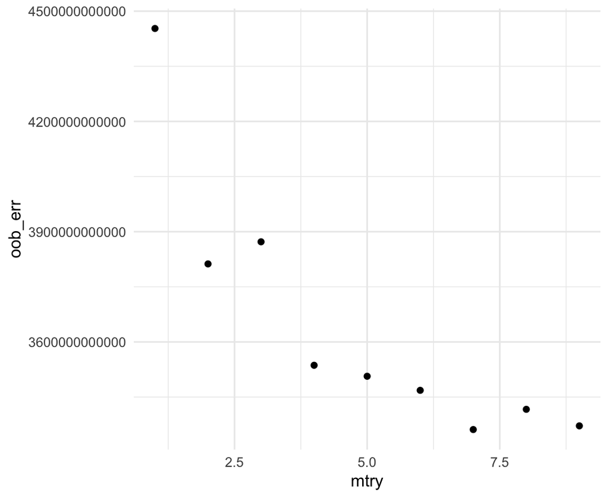

```r
# All Variables
rf_mods <- list()
oob_err <- NULL
test_err <- NULL
for(mtry in 1:9){
  RFfit_right_left_back <- randomForest(player_market_value_euro ~
                           .,
                         data = right_left_back1,
                         mtry = mtry,
                         na.action = na.roughfix,
                         ntree = 200)
  oob_err[mtry] <- RFfit_right_left_back$mse[200]

  cat(mtry," ")
}
## 1  2  3  4  5  6  7  8  9
## 1  2  3  4  5  6  7  8  9
results_DF <- data.frame(mtry = 1:9, oob_err)
ggplot(results_DF, aes(x = mtry, y = oob_err)) + geom_point() + theme_minimal() + xlim(1,9)
```

### Right/Left Midfield

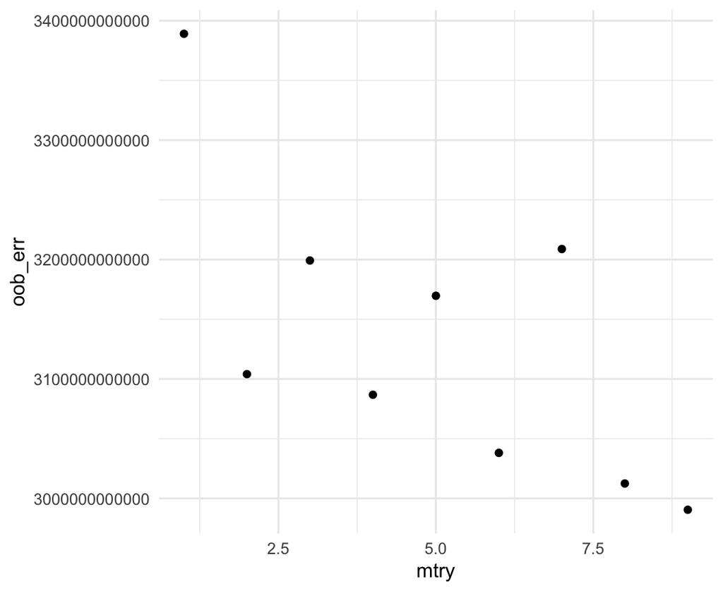

```r
# All Variables
rf_mods <- list()
oob_err <- NULL
test_err <- NULL
for(mtry in 1:9){
  RFfit_right_left_midfielder <- randomForest(player_market_value_euro ~
                           .,
                         data = right_left_midfielder1,
                         mtry = mtry,
                         na.action = na.roughfix,
                         ntree = 200)
  oob_err[mtry] <- RFfit_right_left_midfielder$mse[200]

  cat(mtry," ")
}
## 1  2  3  4  5  6  7  8  9
## 1  2  3  4  5  6  7  8  9
results_DF <- data.frame(mtry = 1:9, oob_err)
ggplot(results_DF, aes(x = mtry, y = oob_err)) + geom_point() + theme_minimal() + xlim(1,9)
```

### Right/Left Winger

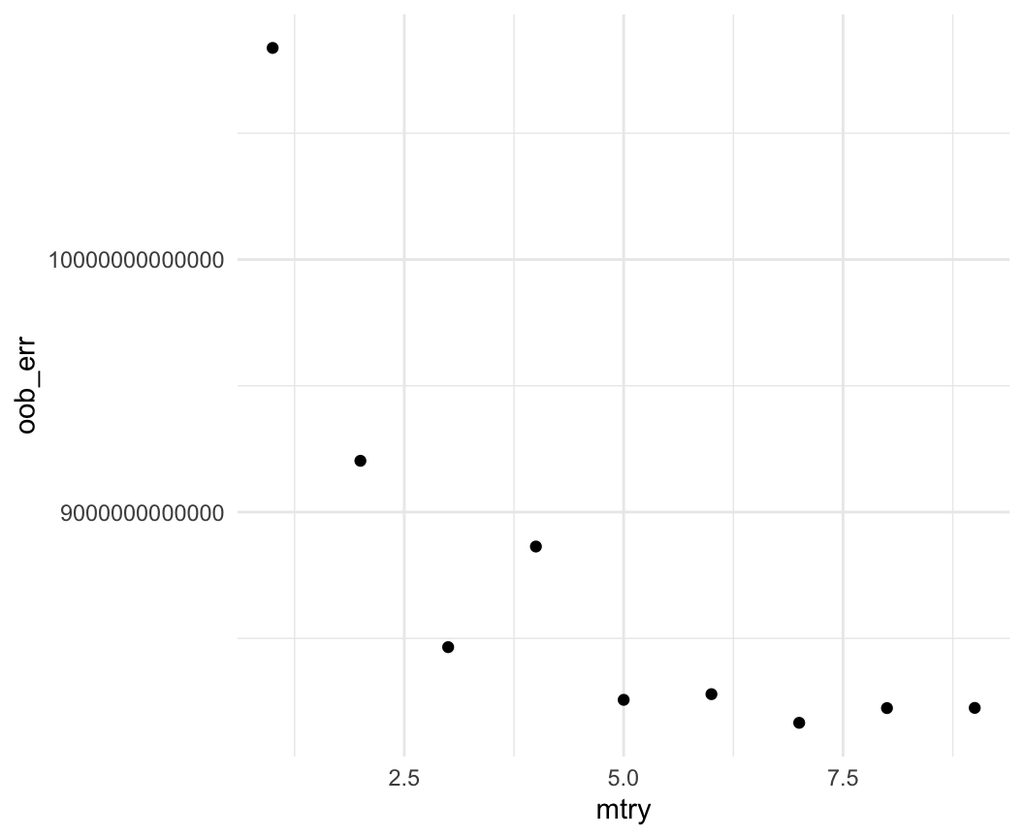

```r
# All Variables
rf_mods <- list()
oob_err <- NULL
test_err <- NULL
for(mtry in 1:9){
  RFfit_winger <- randomForest(player_market_value_euro ~
                           .,
                         data = winger1,
                         mtry = mtry,
                         na.action = na.roughfix,
                         ntree = 200)
  oob_err[mtry] <- RFfit_winger$mse[200]

  cat(mtry," ")
}
## 1  2  3  4  5  6  7  8  9
## 1  2  3  4  5  6  7  8  9
results_DF <- data.frame(mtry = 1:9, oob_err)
ggplot(results_DF, aes(x = mtry, y = oob_err)) + geom_point() + theme_minimal() + xlim(1,9)
```

# Variable Importance Plot

### Attacking Midfield

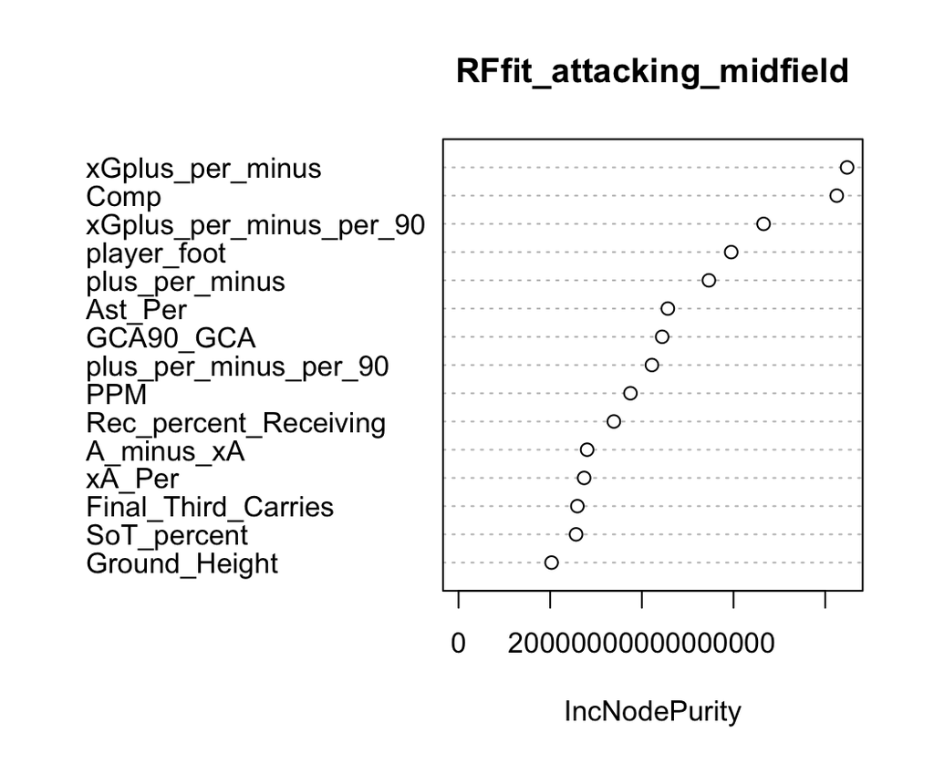

```r
varImpPlot(RFfit_attacking_midfield, n.var = 15)
```

### Central Midfield

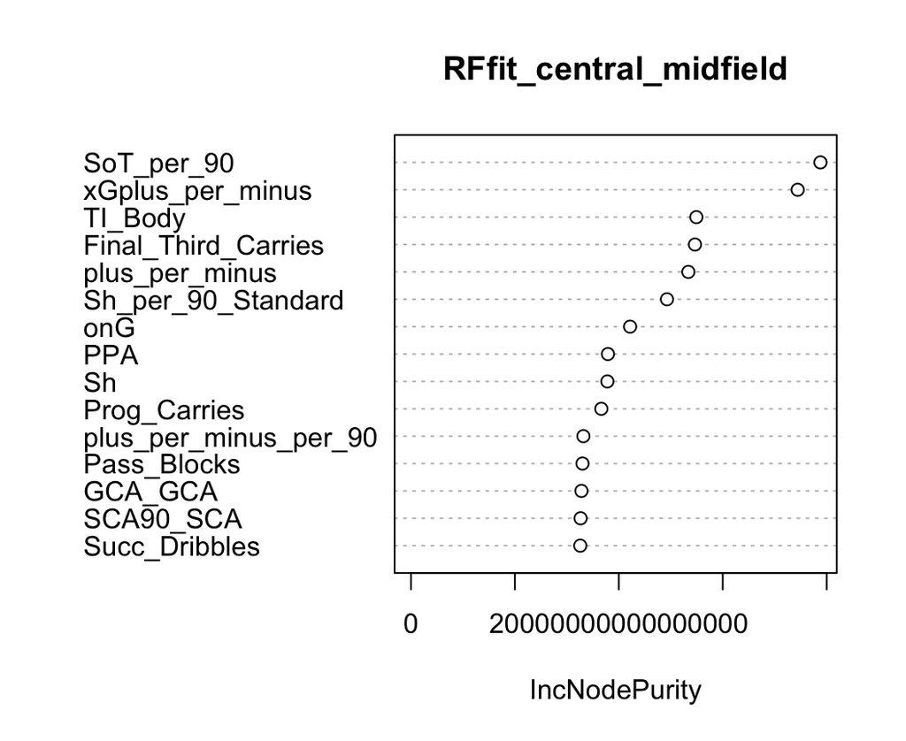

```r
varImpPlot(RFfit_central_midfield, n.var = 15)
```

### Centre Back

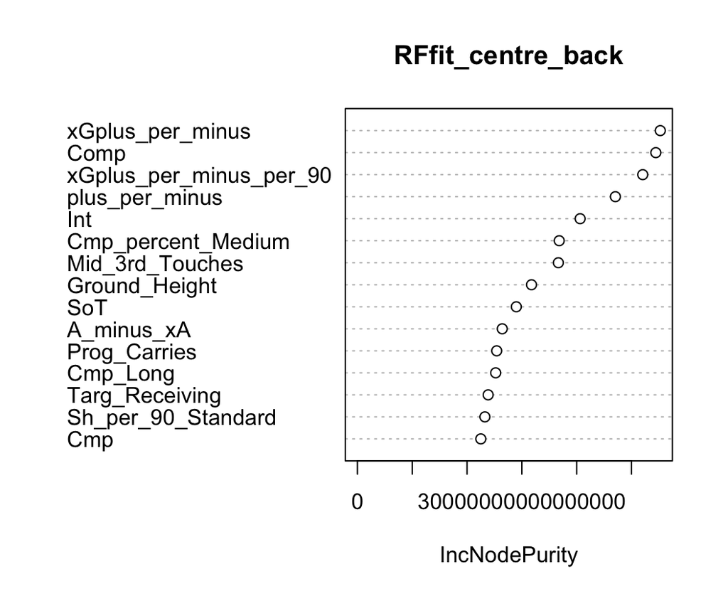

```r
varImpPlot(RFfit_centre_back, n.var = 15)
```

### Centre Forward and Second Striker

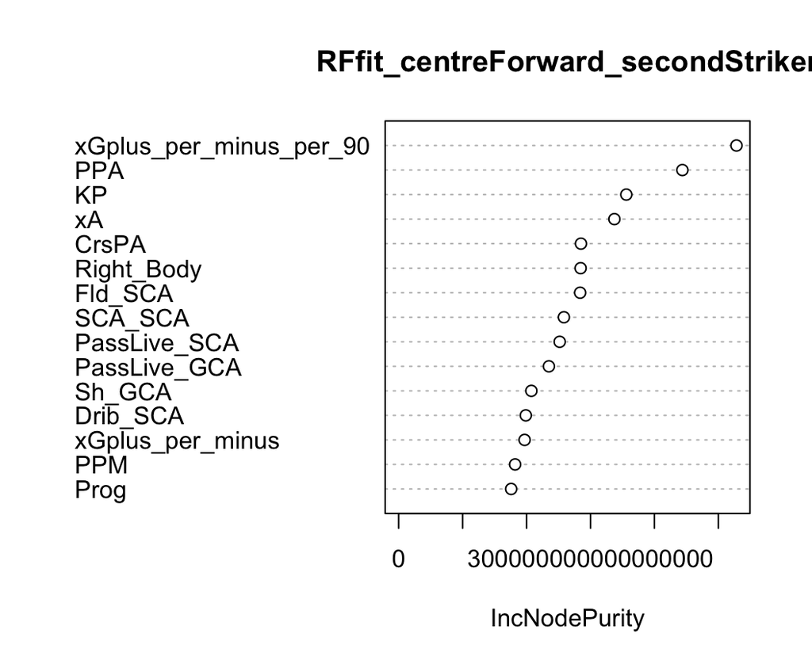

```r
varImpPlot(RFfit_centreForward_secondStriker, n.var = 15)
```

### Right/Left Back

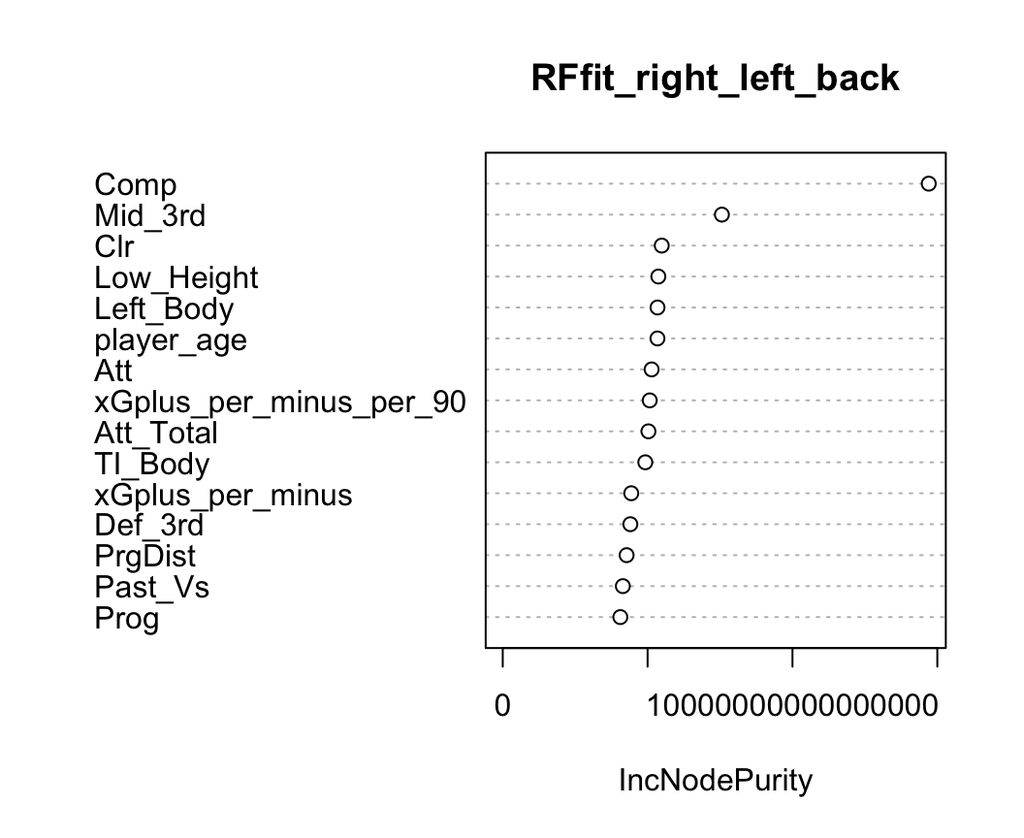

```r
varImpPlot(RFfit_right_left_back, n.var = 15)
```

### Right/Left Midfield

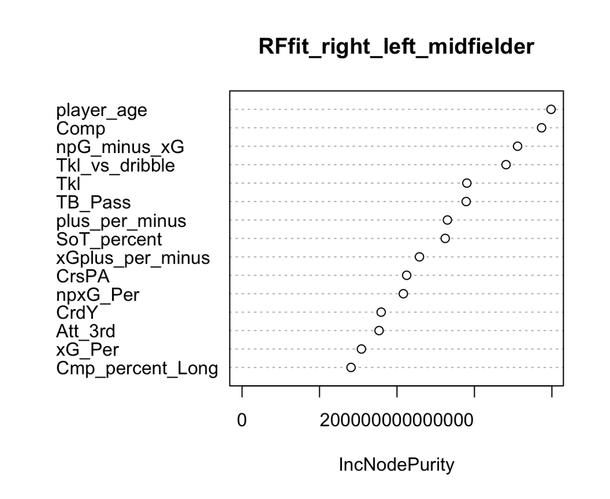

```r
varImpPlot(RFfit_right_left_midfielder, n.var = 15)
```

### Winger

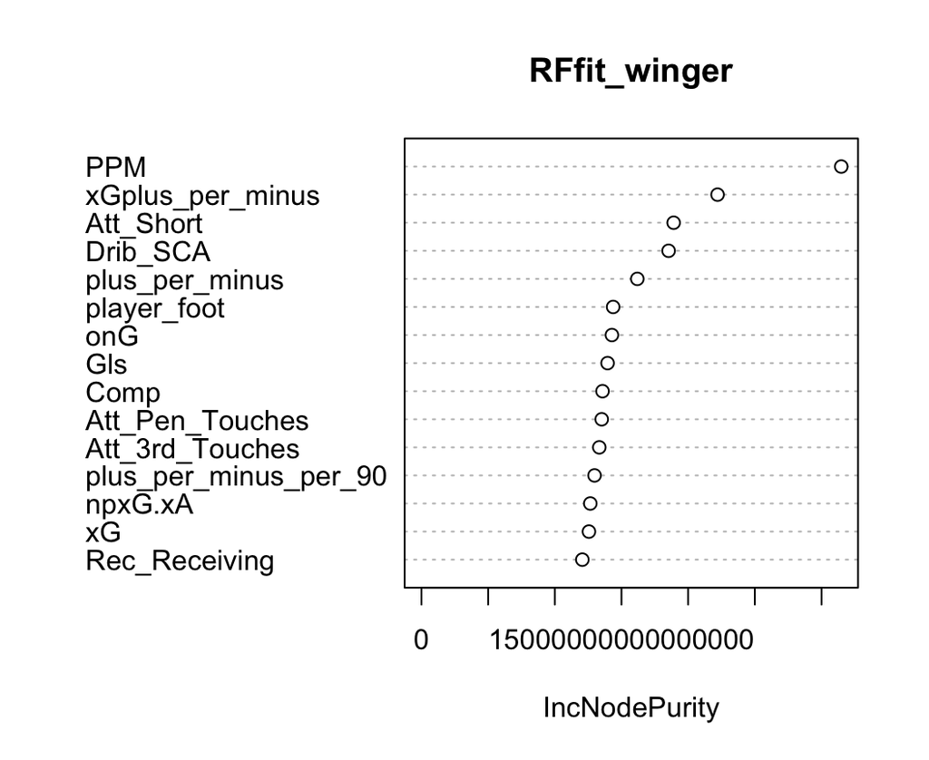

```r
varImpPlot(RFfit_winger, n.var = 15)
```

# Important Variables

### Attacking Midfield

`xG +/-` : Expected Goals Scored minus Expected Goals Allowed

`GCA90_GCA`: Goal Creating Actions per 90

`Ast_Per`:

### Central Midfield

`xG +/-` : Expected Goals Scored minus Expected Goals Allowed

### Centre Back

`xG +/-` : Expected Goals Scored minus Expected Goals Allowed

`int`:

`Cmp_percent_Medium`:

`Mid_3rd_Touches`

### Centre Forward and Second Striker

`xG +/-` : Expected Goals Scored minus Expected Goals Allowed

`PPA`:

### Right/Left Back

`Comp`

`Mod_3rd`

`Low_Height`

### Right/Left Midfield

`SoT_percent`:

`player_age`:

`TB_pass`:

`Comp`:

### Right/Left Winger

`xG +/-` : Expected Goals Scored minus Expected Goals Allowed

`Gls`:

`Rec_receiving`:

# Linear Regression (Coming Soon)

### Attacking Midfield

### Central Midfield

### Centre Back

### Cenre Forward and Second Striker

### Right/Left Back

### Right/Left Midfield

### Right/Left Winger

```r
## Example
# Attacking_LinReg <- lm(player_market_value_euro ~ GCA_GCA + PPA + xGplus_per_minus,
                     #    data = Attacking2)

# summary(Attacking_LinReg)
```

# Appendix

### Standard

`Season_End_Year`: The year at the end of the season.

`Squad`: The team the player plays on.

`Comp`: The league the player plays in.

`Player`: The name of the player.

`Nation`: Nationality of the Player.

`Pos`: The player’s position

`Age`: Current Age

`Born`: Year of Birth

`Matches_Played`: Matches Played

`Starts`: Games Started

`Min`: Minutes Played

`Min_per_90`: Minutes Played divided by 90

`Gls`: Goals

`Ast`: Assists

`G_minus_PK`: Goals minus Penalty Kicks

`PK`: Penalty Kicks Made

`PKatt`: Penalty Kicks Attempted

`CrdY`: Yellow cards

`CrdR`: Red Cards

`Gls_Per`: Goals Scored per 90 minutes

`Ast_Per`: Assists per 90 minutes

`G+A_Per`: Goals and Assists per 90 minutes

`G_minus_PK_Per`: Goals minus Penalty Kicks per 90 minutes

`G+A_minus_PK_Per`: Goals and Assists minus Penalty Kicks per 90 minutes

`xG`: Expected Goals

`npxG`: Non-Penalty Expected Goals

`xA`: xG Assisted

`npxG+xA`: Non Penalty Expected Goals plus xG Assisted

`xG_Per`: Expected Goals per 90 minutes

`xA_Per`: xG Assisted per 90 minutes

`xG+xA_Per`: Expected Goals plus Assist per 90 minutes

`npxG_Per`: Non-Penalty Expected Goals per 90 minutes

`npxG+xA_Per`: Non-Penalty Expected Goals plus xG Assisted per 90 minutes

### Goalkeeping

`Season_End_Year`: The year at the end of the season.

`Squad`: The team the player plays on.

`Comp`: The league the player plays in.

`Player`: The name of the player.

`Nation`: Nationality of the Player.

`Pos`: The player’s position

`Age`: Current Age

`Born`: Year of Birth

`Matches_Played`: Matches Played

`Starts`: Games Started

`Min`: Minutes Played

`Min_per_90`: Minutes Played divided by 90 (Number of games)

`GA`: Goals scored against

`GA90`: Goals scored against per 90 minutes

`SoTA`: Shots on Target Against

`Saves`: Number of saves

`Save_percent`: (Shots on Target Against - Goals Against) / Shots on Target Against *Note that not all shots on target are stopped by the keeper, many will be stopped by defenders. Does not include penalty kicks*

`W`: Wins

`D`: Draws

`L`: Losses

`CS`: Clean sheets (When no goals are scored against)

`CS_percent`: Percentage of matches resulting in clean sheets

`PKatt_Penalty`: Penalty kicks attempted

`PKA_Penalty`: Penalty kicks allowed in

`PKsv_Penalty`:Penalty kicks saved

`PKm_Penalty`: Penalty kicks missed by opposing team

`Save_percent_Penalty`: Penalty Kick Goals Against/Penalty Kick Attempts *Penalty shots that miss the target are not included*

### Advanced Goalkeeping

`Season_End_Year`: The year at the end of the season.

`Squad`: The team the player plays on.

`Comp`: The league the player plays in.

`Player`: The name of the player.

`Nation`: Nationality of the Player.

`Pos`: The player’s position

`Age`: Current Age

`Born`: Year of Birth

`Min_per_90`: Minutes Played divided by 90 (Number of games)

`GA`: Goals scored against

`PKA`: Penalty Kicks Allowed

`FK`: Free Kick Goals Against

`CK`: Corner Kick Goals Against

`OG`: Own Goals Scored Against Keeper

`PSxG`: Post-shot expected goal; based on how likely the goalkeeper is to save the shot. (In-game penalty kicks included)

`PSxG_per_SoT`: Post-shot expected goals per shot on target. (Penalty kicks not included)

`PSxG_plus_minus`: Post-Shot Expected Goals minus Goals Allowed (Positive numbers suggest better luck or an above average ability to stop shots)

`per_90`: Post-Shot Expected Goals minus Goals Allowed per 90 minutes

`Cmp_Launched`: Passes longer than 40 yards completed

`Att_Launched`: Passes longer than 40 yards attempted

`Cmp_percent_Launched`: 40+ yard pass completion rate

`Att_Passes`: Attempted passes excluding goal kicks

`Thr_Passes`: Throws attempted

`Launch_percent_Passes`: Percentage of Passes that were Launched and not Goal Kicks

`AvgLen_Passes`: Average Length of Passes in Yards

`Att_Goal`: Goal Kicks Attempted

`Launch_percent_Goal`: Percentage of Goal Kicks sent more than 40 yards

`AvgLen_Goal`: Average length of goal kicks

`Opp_Crosses`: Opponents attempted crosses into penalty area

`Stp_percent_Crosses`: Percent of crosses into penalty area which were successfully stopped by the goalkeeper

`#OPA_Sweeper`: Number of defensive actions outside of penalty area

`#OPA_per_90_Sweeper`: Defensive actions outside of penalty area per 90 minutes

`AvgDist_Sweeper`: Average distance from goal (in yards) of all defensive actions

### Shooting

`Season_End_Year`: The year at the end of the season.

`Squad`: The team the player plays on.

`Player`: The name of the player.

`Nation`: Nationality of the Player.

`Pos`: The player’s position

`Age`: Current Age

`Born`: Year of Birth

`Mins_per_90`: Minutes played divided by 90

`Gls`: Goals scored or allowed

`SH`: Shots Total

`SoT`: Shots on target

`SoT_percent`: Shots on target percentage, percentage of shots that are on target

`Sh_per_90`: Shots total per 90 minutes

`Sot_per_90`: Shots on target per 90 minutes

`G_per_Sh`: Goals per shot

`G_per_SoT`: Goals per shot on target

`Dist`: Average distance, in yards, from goal of all shots taken

`FK`: Shots from free kicks

`PK`: Penalty Kicks Made

`PKatt`: Penalty Kicks Attempted

`xG`: Expected Goals

`npxG`: Non-Penalty Expected Goals

`npxG_per_Sh`: Non-Penalty Expected Goals per shot

`G_minus_xG`: Goals minus Expected Goals

`npG_minus_npxG`: Non-Penalty Goals minus Non-Penalty Expected Goals

### Passing

`Season_End_Year`: The year at the end of the season

`Squad`: The team the player plays on

`Comp`: The league the player plays in

`Player`: The name of the player

`Nation`: Nationality of the Player

`Pos`: The player’s position

`Age`: Current Age

`Born`: Year of Birth

`Mins_per_90`: Minutes played divided by 90

`Cmp`: Passes Completed

`Cmp_percent`: Pass completion percentage

`TotDist`: Total distance of completed passes in yards

`PrgDist`: Total distance, in yards, that completed passes have traveled towards the opponent’s goal

`Cmp_short`: Completed passes within 5 and 15 yards

`Att_short`: Attempted passes within 5 to 15 yards

`Cmp_percent_Short`: Completion percentage of passes within 5 to 15 yards

`Cmp_Medium`: Completed passes within 15 to 30 yards

`Att_Medium`:Attempted passes within 15 to 30 yards

`Cmp_percent_Medium`: Completion percentage of passes within 15 to 30 yards

`Cmp_Long`: Completed passes over 30 yards

`Att_Long`: Attempted passes over 30 yards

`Cmp_percent_Long`: Completion percentage of passes over 30 yards

`Ast`: Assists

`xA`: Expected Assists

`A_minus_xA`: Assists minus xA

`KP`: Passes directly leading to a shot

`Final_Third`: Completed passes that enter the 1/3 of the pitch closest to the goal

`PPA`: Completed passes into the 18-yard box

`CrsPA`: Completed crosses into the 18-yard box

`Prog`: Completed passes moving the ball towards the opponent’s goal at least 10 yards from its furthest point in the last six passes, or any completed pass into the penalty area

### Pass Types

`Season_End_Year`: The year at the end of the season.

`Squad`: The team the player plays on.

`Comp`: The league the player plays in.

`Player`: The name of the player.

`Nation`: Nationality of the Player.

`Pos`: The player’s position

`Age`: Current Age

`Born`: Year of Birth

`Mins_Per_90`: Minutes played divided by 90

`Att`: Passes Attempted

`Live_Pass`: Live-ball passes

`Dead_Pass`: Dead-ball passes such as a free kick or corner kick

`FK_Pass`: Passes attempted from freekicks

`TB_Pass`: Completed pass sent between back defenders into open space

`Press_Pass`: Passes made while under pressure from opponent

`Sw_Pass`: Passes that travel more than 40 yards of the width of the pitch

`Crs_Pass`: Crosses

`CK_Pass`: Corner Kicks

`In_Corner`: Inswinging Corner Kicks

`Out_Corner`: Outswinging Corner Kicks

`Str_Corner`: Straight Corner Kicks

`Ground_Height`: Ground passes

`Low_Height`: Passes below shoulder-level

`High_Height`: Passes above shoulder-level

`Left_Body`: Passes attempted using left foot

`Right_Body`: Passes attempted using right foot

`Head_Body`: Passes attempted using head

`TI_Body`: Throw-ins Taken

`Other_Body`: Passes attempted using body parts other than the player’s head or feet

`Cmp_Outcomes`: Passes completed

`Off_Outcomes`: Offsides

`Out_Outcomes`: Out of bounds

`In_Outcomes`: Intercepted

`Blocks_Outcomes`: Blocked by an opponent

### Goal and Shot Creation

`Season_End_Year`: The year at the end of the season.

`Squad`: The team the player plays on.

`Comp`: The league the player plays in.

`Player`: The name of the player.

`Nation`: Nationality of the Player.

`Pos`: The player’s position

`Age`: Current Age

`Born`: Year of Birth

`Mins_Per_90`: Minutes played divided by 90

`SCA_SCA`: Shot-creating Actions

`SCA90__SCA`: Shot-creating Actions per 90 minutes

`PassLive_SCA`: Completed live-ball passes that lead to a shot attempt

`PassDead_SCA`: Completed dead-ball passes that lead to a shot attempt (Includes free kicks, corner kicks, kick offs, throw-ins and goal kicks)

`Drib_SCA`: Successful dribbles that lead to a shot attempt

`Sh_SCA`: Shots that lead to another shot attempt

`Fld_SCA`: Fouls drawn that lead to a shot attempt

`Def_SCA`: Defensive actions that lead to a shot attempt

`GCA_GCA`: The offensive actions directly leading to a goal, such as passes, dribbles and drawing fouls

`GCA90_GCA`: Goal-Creating Actions per 90 minutes

`PassLive_GCA`: Completed live-ball passes that lead to a goal

`PassDead_GCA`: Completed dead-ball passes that lead to a goal (Includes free kicks, corner kicks, kick offs, throw-ins and goal kicks)

`Drib_GCA`: Successful dribbles that lead to a goal

`Sh_GCA`: Shots that lead to another goal-scoring shot

`Fld_GCA`: Fouls drawn that lead to a goal

`Def_GCA`: Defensive actions that lead to a goal

### Defensive Actions

`Season_End_Year`: The year at the end of the season.

`Squad`: Team

`Comp`: Completions

`Player`: Players name

`Nation`: Players Nationality

`Pos`: Players position

`Age`: Current age

`Born`: Year of Birth

`Mins_Per_90`: Minutes played divided by 90

`Tkl`: Number of players tackled

`TklW`: Tackles in which the tackler’s team won possession of the ball

`Def_3rd`: Tackles in defensive 1/3

`Mid_3rd`: Tackles in middle 1/3

`Att_3rd`: Tackles in attacking 1/3

`Tkl_vs_dribble`: Number of dribblers tackled

`Att_vs_dribble`: Number of times dribbled past plus number of tackles

`Press_Pressures`: Number of times applying pressure to opposing player who is receiving, carrying or releasing the ball

`Succ_Pressures`: Number of times the squad gained possession withing five seconds of applying pressure

`Successful_Pressure_Percent`: Percentage of time the squad gained possession withing five seconds of applying pressure

`Def_3rd_Pressures`: Number of times applying pressure to opposing player who is receiving, carrying or releasing the ball, in the defensive 1/3

`Mid_3rd_Pressures`:Number of times applying pressure to opposing player who is receiving, carrying or releasing the ball, in the middle 1/3

`Att_3rd_Pressures`: Number of times applying pressure to opposing player who is receiving, carrying or releasing the ball, in the attacking 1/3

`Blocks`: Number of times blocking the ball by standing in its path

`Sh_Blocks`: Number of times blocking a shot by standing in its path

`ShSv_Blocks`: Number of times blocking a shot that was on target, by standing in its path

`Pass_Blocks`: Number of times blocking a pass by standing in its path

`Int`: Interceptions

`Tkl+Int`: Number of players tackled plus number of interceptions

`Clr`: Clearances

`Err`: Mistakes leading to an opponent’s shot

### Possessions

`Season_End_Year`: The year at the end of the season.

`Squad`: Team

`Comp`: Completions

`Player`: Players name

`Nation`: Players Nationality

`Pos`: Players position

`Age`: Current age

`Born`: Year of Birth

`Touches`: Number of times a player touched the ball

`Def_Pen`: Touches in defensive penalty area

`Def_3rd_Touches`: Touches in defensive 1/3

`Mid_3rd_Touches`: Touches in middle 1/3

`Att_3rd_Touches`: Touches in attacking 1/3

`Att_Pen_Touches`: Touches in attacking penalty area

`Live_Touches`: Live-ball touches

`Succ_Dribbles`: Dribbles Completed Successfully

`Att_Dribbles : Dribbles Attempted

`Succ_percent_Dribbles`: Percentage of Dribbles Completed Successfully

`#Pl_Dribbles`: Number of Players Dribbled Past

`Megs_Dribbles`: Number of times a player dribbled the ball through an opposing player’s legs

`Carries`: Number of times the player controlled the ball with their feet

`TotDist_Carries`: Total distance, in yards, a player moved the ball while controlling it with their feet, in any direction

`PrgDist_Carries`: Progressive Distance; Total distance, in yards, a player moved the ball while controlling it with their feet towards the opponent’s goal

`Prog_Carries`: Carries that move the ball towards the opponent’s goal at least 5 yards, or any carry into the penalty area

`Final_Third_Carries`: Carries that enter the 1/3 of the pitch closest to the goa

`CPA_Carries`: Carries into the 18-yard box

`Mis_Carries`: Number of times a player failed when attempting to gain control of a ball

`Dis_Carries`: Number of times a player loses control of the ball after being tackled by an opposing player

`Targ_Receiving`: Number of times a player was the target of an attempted pass

`Rec_Receiving`: Number of times a player successfully received a pass

`Rec_percent_Receiving`: Passes Received Percentage

`Prog_Receiving`: Progressive Passes Received

### Playing Time

`Season_End_Year`: The year at the end of the season.

`Squad`: The team the player plays on.

`Comp`: The league the player plays in.

`Player`: The name of the player.

`Nation`: Nationality of the Player.

`Pos`: The player’s position

`Age`: Current Age

`Born`: Year of Birth

`MP`: Matches Played

`Min`: Minutes

`Min_per_MP`: Minutes per Match Playerd

`Min_percent_Playing.Time`: Percentage of team’s total minutes in which player was on the pitch

`Mins_per_90`: Minutes played divided by 90

`Starts`: Game or games started by player

`Mn_per_Start`: Minutes Per Match Started

`Compl`: Complete matches played

`Subs`: Games as sub

`Mn_per_Sub`: Minutes Per Substitution

`unSub`: Games as an unused substitute

`PPM`: Points per Match

`onG`: Goals scored by team while on pitch

`onGA`: Goals allowed by team while on pitch

`plus_per_minus`: Goals scored minus goals allowed by the team while the player was on the pitch

`plus_per_minus_per_90`: Goals scored minus goals allowed by the team while the player was on the pitch per 90 minutes played

`On_minus_Off`:

`onxG`: Expected goals by team while on pitch

`onxGA`: Expected goals allowed by team while on pitch

`xGplus_per_minus`: Expected goals scored minus expected goals allowed by the team while the player was on the pitch

`xGplus_per_minus_per_90`: Expected goals scored minus expected goals allowed by the team while the player was on the pitch per 90 minutes played

### Misc

`Season_End_Year`: The year at the end of the season.

`Squad`: The team the player plays on.

`Comp`: The league the player plays in.

`Player`: The name of the player.

`Nation`: Nationality of the Player.

`Pos`: The player’s position

`Age`: Current Age

`Mins_Per_90`: Minutes played divided by 90

`CrdY`: Yellow cards

`2CrdY`: Second Yellow Card

`Fls`: Fouls committed

`Fld`: Fouls drawn

`Off`: Off-sides

`Crs`: Crosses

`Int`: Interceptions

`TklW`: Tackles in which the tackler’s team won possession of the ball

`PKwon`: Penalty Kicks Won

`PKcon`: Penalty Kicks Conceded

`OG`: Own Goals

`Recov`: Number of loose balls recovered

`Won_Aerial`: Aerials won

`Lost_Aerial`: Aerials lost

`Won_percent_Aerial`: Minimum .97 aerial duels per squad game to qualify as a leader

### Market Values Table

`squad`: The team the player plays on.

`player_name`: The player’s name

`player_url`: The player’s URL on transfermarkt

`player_position`: The player’s position

`player_age`: The player’s age

`player_name`: The player’s name

`player_nationality`: The player’s nationality

`current_club`: The club the player currently plays on

`player_height_mtrs`: The player’s height

`player_foot`: The player’s dominant foot

`joined_from`: The former club the player joined from

`contract_expiry`: The time when the player’s contract expires

`player_market_value_euro`: The valuation of the player in Euros

`date_joined`: The date the player joined